emphasis · covariate biology

# The biological meaning of D

phylogenetic isolation as a diversification covariate · F. Richter · USI · 2026-07-22

In one lineD is a lineage's *phylogenetic isolation relative to its contemporaries* — the signed deviation of its time-since-last-speciation from the clade mean. It is the same quantity that underlies evolutionary distinctiveness and, inversely, tip diversification rate; its coefficient β<sub>D</sub> is the model's handle on the century-old question of whether speciation is age-structured.

§1

## A century-old question

Since Yule (1925) the default model of a diversifying clade has been a *memoryless* birth process: every lineage speciates at the same instantaneous rate, independent of how long it has existed. Nee, May & Harvey (1994) built the standard likelihood of a reconstructed tree on exactly this assumption. Yet real phylogenies persistently violate it in two ways a constant-rate process cannot produce: diversification *slows down* toward the present (Pybus & Harvey's γ<0), and clades harbour long, isolated terminal branches — *living fossils* — lineages that have persisted for tens of millions of years without splitting. Two repairs dominate: making the rate depend on standing diversity (diversity-dependence), and making it depend on lineage *age* — protracted speciation, where speciation takes time to complete (Rosindell et al. 2010; Etienne & Rosindell 2012), and explicit age-dependent birth–death models (Hagen et al. 2018). The covariate D operationalises this second repair at the level of a single lineage.

§2

## What D is, exactly

Let t<sub>s</sub> be the last time lineage s speciated and I<sub>s</sub>=t−t<sub>s</sub> its *isolation time* — the length of its current pendant edge. With N lineages alive and mean isolation M:

D<sub>s</sub> = I<sub>s</sub> − M

So D is simply the *centered pendant edge*: how much longer (D>0) or shorter (D<0) a lineage has gone without speciating than its living peers. Because Σ<sub>s</sub>D<sub>s</sub>=0 by construction, D carries no information about the clade as a whole — only about the *relative position* of a lineage within it.

This ties D to two familiar measures. For a present-day lineage, I<sub>s</sub> is its terminal branch length, so D at the tips is the *centered terminal branch*: the raw material of **evolutionary distinctiveness** (Isaac et al. 2007 — long pendant = distinct, "on the EDGE") and, inversely, of the **tip diversification rate** DR (Jetz et al. 2012 — short pendant = fast recent diversification). D>0 is thus a relatively isolated, relictual lineage; D<0 a recently-radiated one. Evaluated at every branching event, D makes this instantaneous and relative.

§3

## D across the atlas

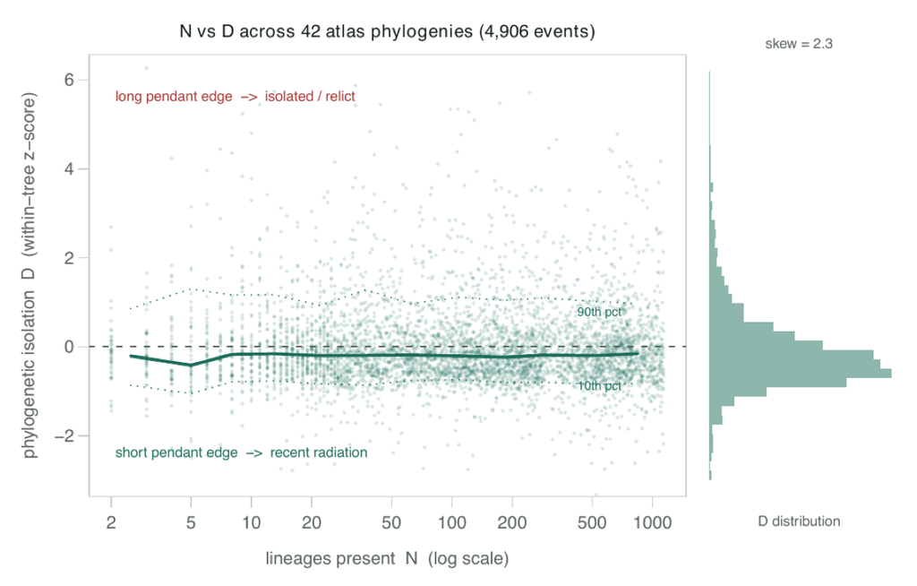

| Clade | pendant (Myr) | crown (Myr) | pendant / crown |
| --- | --- | --- | --- |
| Salamanders (Caudata) | 427.8 | 429.7 | 0.996 |
| Night lizards (Xantusiidae) | 103.3 | 104.3 | 0.990 |
| Toucans (Ramphastidae) | 77.5 | 78.2 | 0.991 |
| Ibises (Threskiornithidae) | 50.2 | 50.8 | 0.987 |
| Petrels (Procellariidae) | 79.3 | 80.7 | 0.983 |
| Pikas (Ochotonidae) | 44.8 | 45.7 | 0.981 |
| Iguanas (Iguanidae) | 58.7 | 67.7 | 0.867 |

**Table 1.** The most isolated lineage in a sample of atlas clades: its pendant edge as a fraction of crown age. A ratio near 1 means a lineage isolated for essentially the clade's entire history.

§4

## What β<sub>D</sub> estimates

Placed in the rate, λ<sub>s</sub> = f(⋯ + β<sub>D</sub>D<sub>s</sub>), the coefficient β<sub>D</sub> tests *age-dependent speciation* directly, and its sign is interpretable:

β<sub>D</sub> > 0 isolated, long-pendant lineages speciate *faster* — an "age advantage": the longer a lineage persists, the more likely to split. The signature of protracted speciation (reproductive isolation, or ecological opportunity, accumulating with time), and what generates diversification slowdowns.

β<sub>D</sub> < 0 recently-split lineages speciate faster — diversification concentrated in young radiations, older lineages becoming evolutionary "dead wood."

β<sub>D</sub> = 0 the memoryless (Yule / Nee) null — speciation is age-independent.

Because Σ<sub>s</sub>D<sub>s</sub>=0, β<sub>D</sub> acts *only* on which lineage splits, never on the clade's overall rate: a pure test of internal, age-structured heterogeneity, cleanly separated from diversity-dependence (carried by N). This is why D and N are the two orthogonal covariates — one asks *when* the clade diversifies, the other *which lineages within it do*.

§5

**References.** Yule (1925) *Phil. Trans. R. Soc. B* 213:21. Nee, May & Harvey (1994) *Phil. Trans. R. Soc. B* 344:305. Pybus & Harvey (2000) *Proc. R. Soc. B* 267:2267. Isaac, Turvey, Collen, Waterman & Baillie (2007) *PLoS ONE* 2:e296 (EDGE). Jetz, Thomas, Joy, Hartmann & Mooers (2012) *Nature* 491:444 (DR). Rosindell, Cornell, Hubbell & Etienne (2010) *Ecol. Lett.* 13:716; Etienne & Rosindell (2012) *Syst. Biol.* 61:204. Hagen, Hartmann, Steel & Stadler (2018) *Syst. Biol.* 67.

*Data:* 42 Phylo-Atlas chronograms, 4,906 events; all numbers computed, not estimated.